# The effect of temperature on Podosphera xanthii germination and branching

The statistical method undertaken in analysing the effect of temperature on the germination and branching of *P. xanthii*.

Paul Melloy https://PaulMelloy.github.io (The University of Queensland)https://uq.edu.au  
2022-05-31

Load R libraries required for analysis

```r
library(data.table) # data structure, cleaning and formatting
library(mgcv) # gam statistical models
library(rstanarm) # Bayesian statistical models
library(ggplot2) # graphing
library(MASS) # logistical ordinal regression functions, among other things
```

Read in data

```r
g_tm <- fread("cache/germination_temperature.csv")
br_tm <- fread("cache/branching_temperature.csv")
br_tm2 <- fread("cache/Tm_branches.csv")
```

## Impact of Temperature on *P. xanthii* germination

Peek at the data

```r
head(g_tm)
```

```
   Tm i_period leaf germ_conidia non_germ_conidia
1:  8       12    1            0              100
2:  8       12    1            0              100
3:  8       12    2            0              100
4:  8       12    2            0              100
5:  8       24    1            0              100
6:  8       24    1            0              100
```

```r
str(g_tm)
```

```
Classes 'data.table' and 'data.frame':  128 obs. of  5 variables:
 $ Tm              : int  8 8 8 8 8 8 8 8 8 8 ...
 $ i_period        : int  12 12 12 12 24 24 24 24 36 36 ...
 $ leaf            : int  1 1 2 2 1 1 2 2 1 1 ...
 $ germ_conidia    : int  0 0 0 0 0 0 0 0 0 0 ...
 $ non_germ_conidia: int  100 100 100 100 100 100 100 100 100 100 ...
 - attr(*, ".internal.selfref")=<externalptr>
```

How many leaves were inoculated?

```r
length(unique(g_tm$Tm)) *           # Temperature incubators
   length(unique(g_tm$leaf)) *      # individual leaves
   length(unique(g_tm$i_period))    # Sampling times
```

```
[1] 64
```

Add the number of leaves sampled at 36 hours to count germ-tube branching.

```r
br_tm
```

```
    Tm branches rep conidia
 1:  8        0   1     100
 2:  8        0   2     100
 3:  8        1   1       0
 4:  8        1   2       0
 5:  8        2   1       0
 6:  8        2   2       0
 7:  8        3   1       0
 8:  8        3   2       0
 9: 17        0   1      70
10: 17        0   2      70
11: 17        1   1      15
12: 17        1   2      12
13: 17        2   1      15
14: 17        2   2      18
```

[output cut: 51 more lines]

```r
length(unique(br_tm$Tm)) *           # Temperature incubators
   length(unique(br_tm$rep))       # Reps or individual leaves?
```

```
[1] 16
```

### Visualise the raw data

Let’s plot the data over time, we will need to omit temperatures 8 and 35 where no germination was observed.

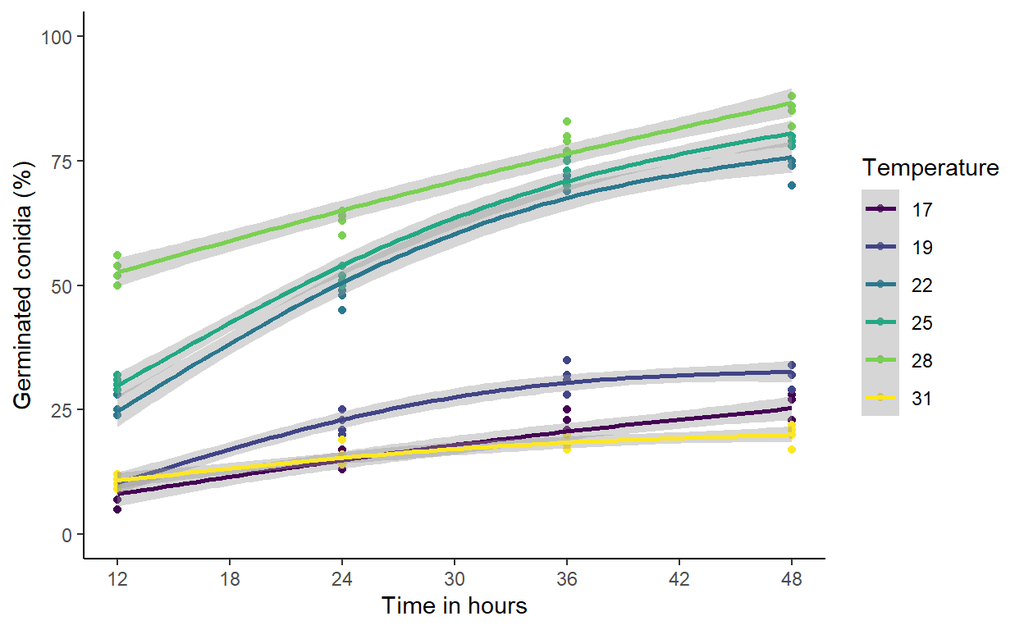

```r
g_tm[Tm != 8 &
        Tm != 35,] |>
   ggplot(aes(x = i_period, y = germ_conidia, colour = as.factor(Tm))) +
   geom_point()+
   geom_smooth(method = "gam",formula = y ~ s(x, k = 3))+
   scale_color_viridis_d()+
   xlab("Time in hours")+
   ylab("Germinated conidia (%)")+
   labs(colour = "Temperature")+
   theme_classic()+
   scale_x_continuous(limits = c(12,48), breaks = c(12,18,24,30,36,42,48))+
   scale_y_continuous(limits = c(0,100), n.breaks = 5)
```

Now lets plot germination over temperature separating by infection period.

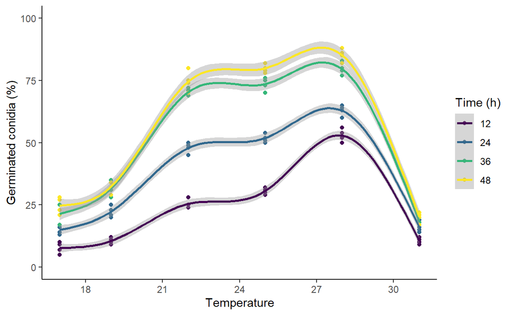

```r
g_tm[Tm != 8 &
        Tm != 35,] |>
   ggplot(aes(x = Tm, y = germ_conidia, colour = as.factor(i_period))) +
   geom_point()+
   geom_smooth(method = "gam",formula = y ~ s(x, k = 6))+
   scale_color_viridis_d()+
   xlab("Temperature")+
   ylab("Germinated conidia (%)")+
   labs(colour = "Time (h)")+
   theme_classic()+
   scale_x_continuous(breaks = c(18,21,24,27,30))+
   scale_y_continuous(limits = c(0,100), n.breaks = 5)
```

Lets further evaluate this fit. However instead of fitting a temperature as a separate random effect, as depicted in the above plot, we will define temperature as a separate continuous predictor that may or may not interact with infection period.

```r
m1 <- gam(cbind(germ_conidia, non_germ_conidia) ~ s(i_period, k=3) + s(Tm, k =4),
          data = g_tm[Tm != 8 & Tm != 35,],
          family = "binomial")
summary(m1)
```

```
Family: binomial
Link function: logit

Formula:
cbind(germ_conidia, non_germ_conidia) ~ s(i_period, k = 3) +
    s(Tm, k = 4)

Parametric coefficients:
            Estimate Std. Error z value Pr(>|z|)
(Intercept) -0.51709    0.02445  -21.15   <2e-16 ***
---
Signif. codes:  0 '***' 0.001 '**' 0.01 '*' 0.05 '.' 0.1 ' ' 1

Approximate significance of smooth terms:
              edf Ref.df Chi.sq p-value
s(i_period) 1.974  1.999    627  <2e-16 ***
s(Tm)       2.995  3.000   1604  <2e-16 ***
---
Signif. codes:  0 '***' 0.001 '**' 0.01 '*' 0.05 '.' 0.1 ' ' 1

R-sq.(adj) =  0.894   Deviance explained = 89.3%
UBRE = 2.2188  Scale est. = 1         n = 96
```

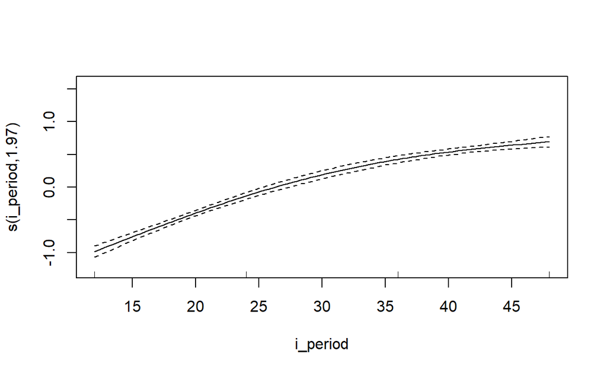

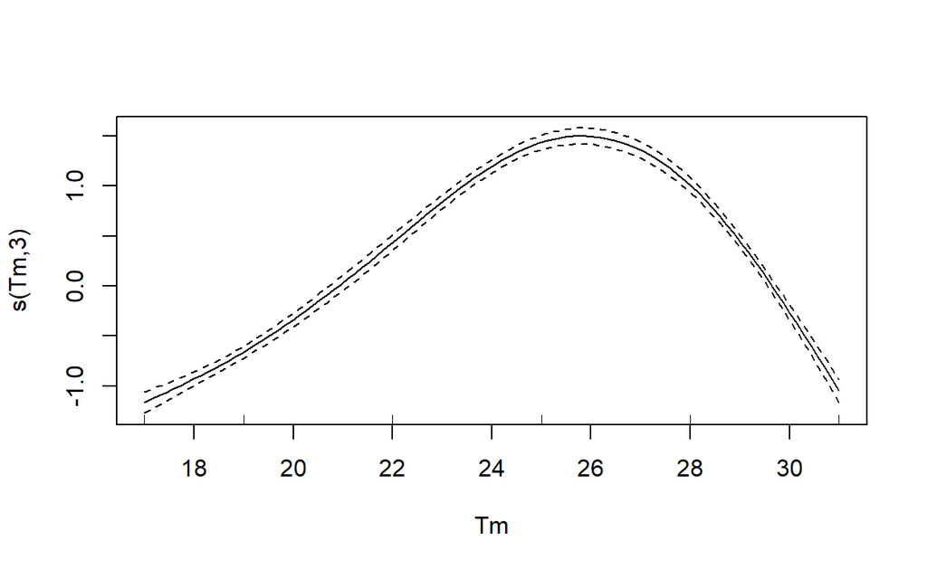

```r
plot(m1)
```

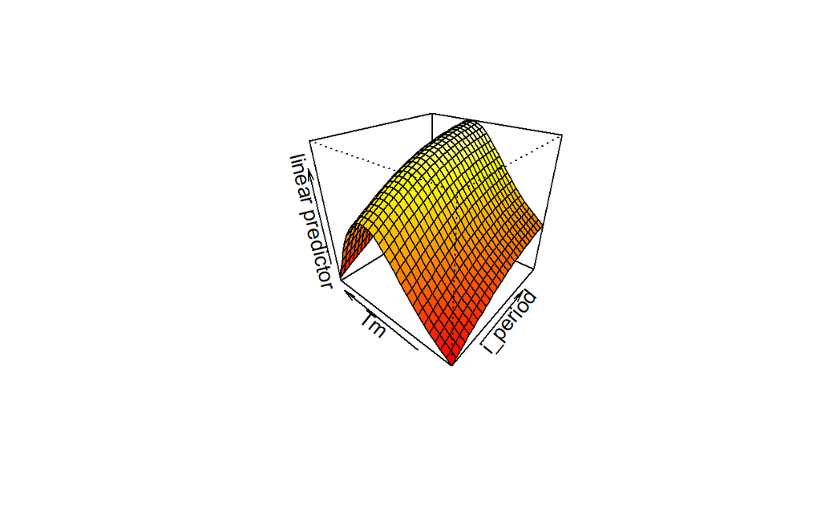

```r
vis.gam(m1,
        theta = -50, # horizontal rotation
        phi = 30, # vertical rotation
        n.grid = max(g_tm$Tm) - min(g_tm$Tm) # grid cells
        )
```

Model two we will investigate whether there is an interaction between temperature and infection period.

```r
m2 <- gam(cbind(germ_conidia, non_germ_conidia) ~ te(i_period, Tm, k = 4),
          data = g_tm[Tm != 8 & Tm != 35,],
          family = "binomial")
summary(m2)
```

```
Family: binomial
Link function: logit

Formula:
cbind(germ_conidia, non_germ_conidia) ~ te(i_period, Tm, k = 4)

Parametric coefficients:
            Estimate Std. Error z value Pr(>|z|)
(Intercept) -0.47572    0.02497  -19.05   <2e-16 ***
---
Signif. codes:  0 '***' 0.001 '**' 0.01 '*' 0.05 '.' 0.1 ' ' 1

Approximate significance of smooth terms:
                  edf Ref.df Chi.sq p-value
te(i_period,Tm) 11.91  13.42   1919  <2e-16 ***
---
Signif. codes:  0 '***' 0.001 '**' 0.01 '*' 0.05 '.' 0.1 ' ' 1

R-sq.(adj) =  0.912   Deviance explained = 91.2%
UBRE = 1.8064  Scale est. = 1         n = 96
```

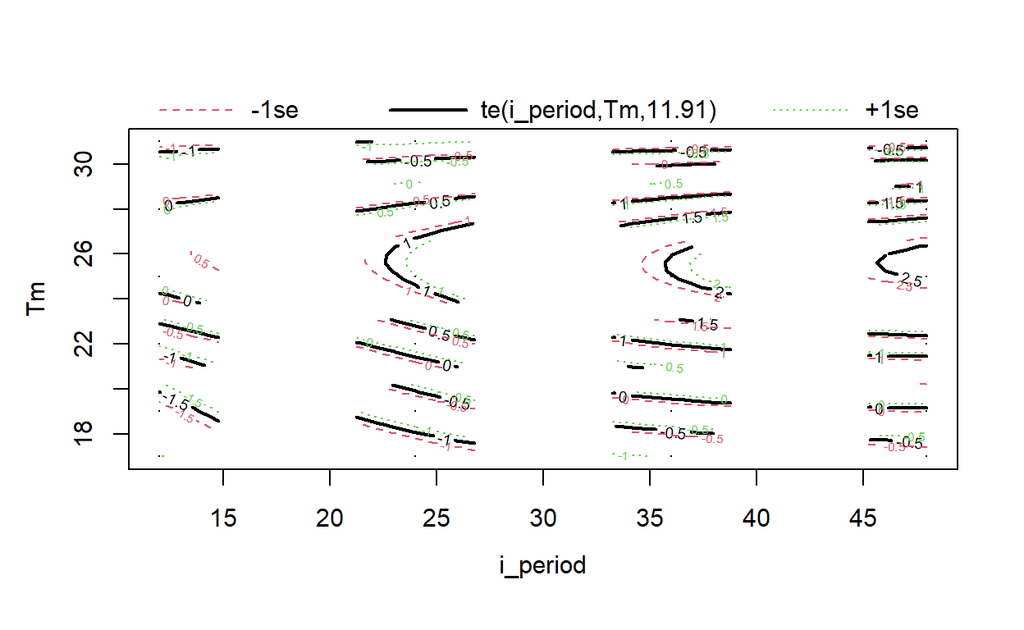

```r
plot(m2)
```

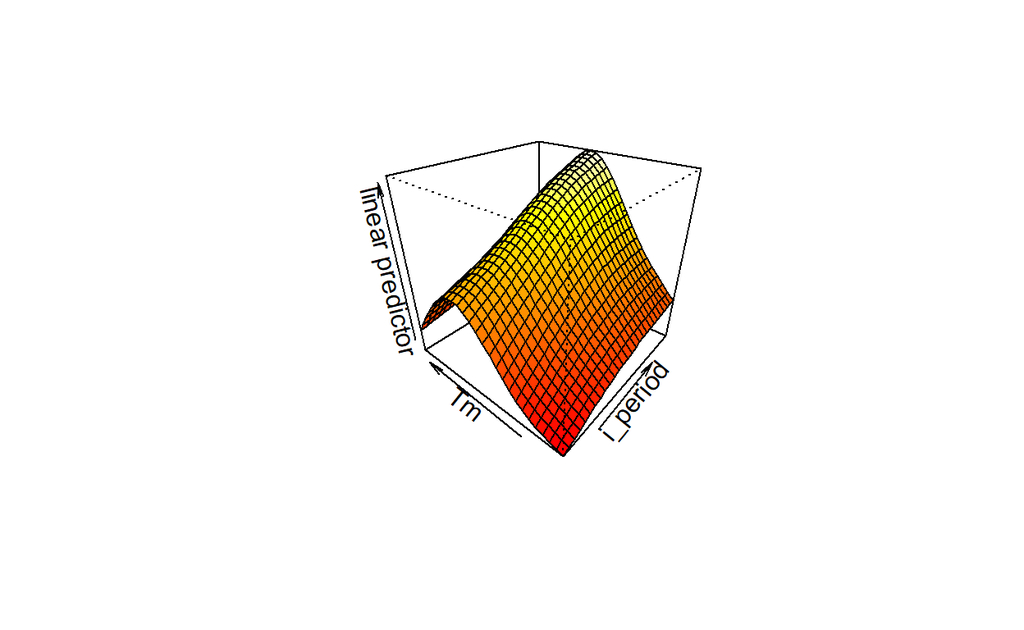

```r
vis.gam(m2,
        theta = -50, # horizontal rotation
        phi = 30, # vertical rotation
        n.grid = max(g_tm$Tm) - min(g_tm$Tm) # grid cells
        )
```

This model shows slightly higher R squared and ‘explained deviance’ values, with a lower UBRE value indicating that model two (`m2`) is the better model.

Lets compare the models against each other.

```r
anova(m1,m2, test = "Chisq")
```

```
Analysis of Deviance Table

Model 1: cbind(germ_conidia, non_germ_conidia) ~ s(i_period, k = 3) +
    s(Tm, k = 4)
Model 2: cbind(germ_conidia, non_germ_conidia) ~ te(i_period, Tm, k = 4)
  Resid. Df Resid. Dev     Df Deviance  Pr(>Chi)
1    90.001     297.07
2    81.582     243.60 8.4188   53.473 1.339e-08 ***
---
Signif. codes:  0 '***' 0.001 '**' 0.01 '*' 0.05 '.' 0.1 ' ' 1
```

This confirms that model two is the better model and explains more of the deviance.

P-splines use a penalised least-square method to fit the model and are better in non-normal distributions. Lets try p splines to see if we can improve the fit.

```r
m3 <- gam(cbind(germ_conidia, non_germ_conidia) ~ s(i_period, k=3) + s(Tm, k =4, bs = "ps"),
          data = g_tm[Tm != 8 & Tm != 35,],
          family = "binomial")
summary(m3)
```

```
Family: binomial
Link function: logit

Formula:
cbind(germ_conidia, non_germ_conidia) ~ s(i_period, k = 3) +
    s(Tm, k = 4, bs = "ps")

Parametric coefficients:
            Estimate Std. Error z value Pr(>|z|)
(Intercept) -0.52369    0.02461  -21.28   <2e-16 ***
---
Signif. codes:  0 '***' 0.001 '**' 0.01 '*' 0.05 '.' 0.1 ' ' 1

Approximate significance of smooth terms:
              edf Ref.df Chi.sq p-value
s(i_period) 1.974  1.999  631.5  <2e-16 ***
s(Tm)       2.996  3.000 1655.2  <2e-16 ***
---
Signif. codes:  0 '***' 0.001 '**' 0.01 '*' 0.05 '.' 0.1 ' ' 1

R-sq.(adj) =  0.919   Deviance explained = 91.7%
UBRE = 1.5232  Scale est. = 1         n = 96
```

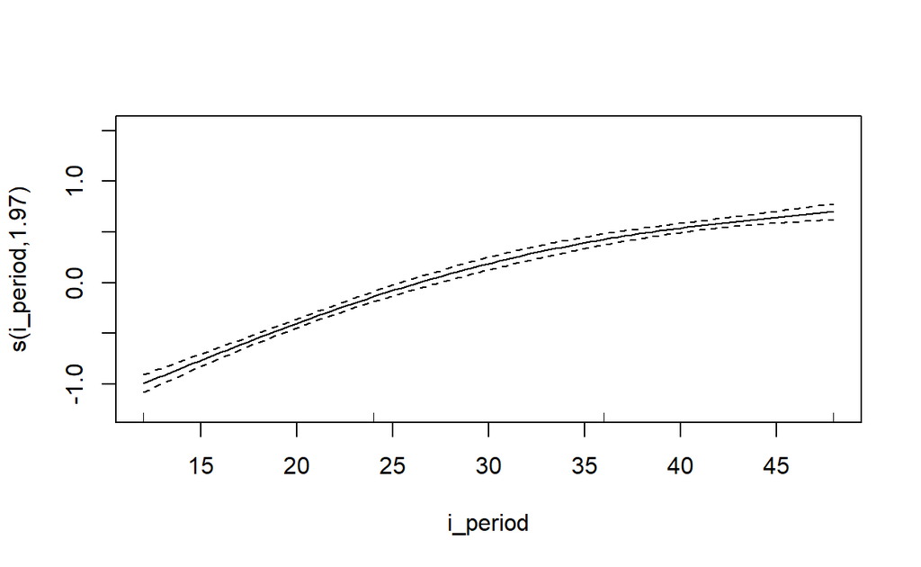

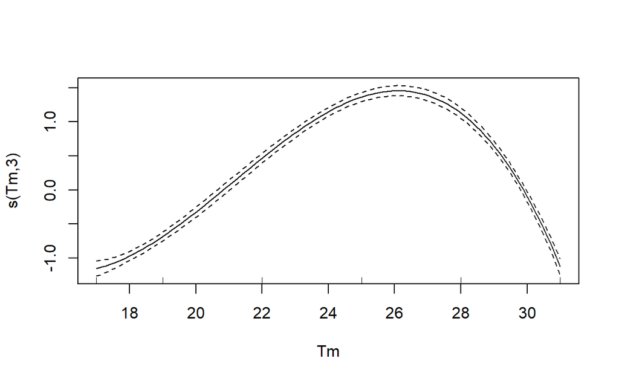

```r
plot(m3)
```

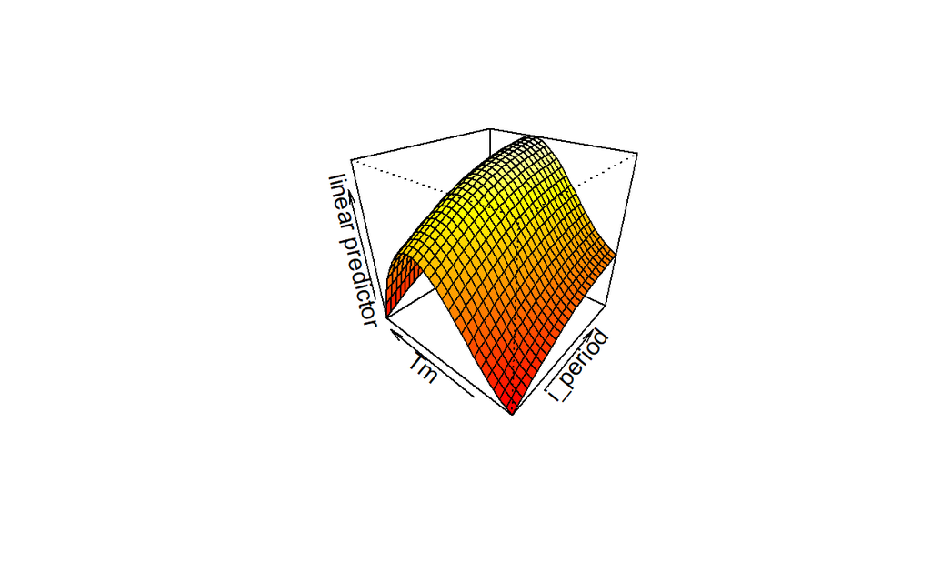

```r
vis.gam(m3,
        theta = -50, # horizontal rotation
        phi = 30, # vertical rotation
        n.grid = max(g_tm$Tm) - min(g_tm$Tm) # grid cells
        )
```

The P-splines have improved the predictive ability of the model with a lower UBRE, improved the R squared value and explained deviance. We can also see that the curve has been shifted slightly up towards 28C.

Lets compare the models two and three to against each other.

```r
anova(m2,m3, test = "Chisq")
```

```
Analysis of Deviance Table

Model 1: cbind(germ_conidia, non_germ_conidia) ~ te(i_period, Tm, k = 4)
Model 2: cbind(germ_conidia, non_germ_conidia) ~ s(i_period, k = 3) +
    s(Tm, k = 4, bs = "ps")
  Resid. Df Resid. Dev      Df Deviance Pr(>Chi)
1    81.582     243.60
2    90.001     230.29 -8.4188   13.308
```

The models show no significant difference therefore we should use the simpler model, model three (`m3`). Model three also shows a better fit to the data.

Next lets see if cyclic versions of the p-splines `"cp"` improve this fit further.

```r
m4 <- gam(cbind(germ_conidia, non_germ_conidia) ~ s(i_period, k=3) + s(Tm, k =4, bs = "cp"),
          data = g_tm[Tm != 8 & Tm != 35,],
          family = "binomial")
summary(m4)
```

```
Family: binomial
Link function: logit

Formula:
cbind(germ_conidia, non_germ_conidia) ~ s(i_period, k = 3) +
    s(Tm, k = 4, bs = "cp")

Parametric coefficients:
            Estimate Std. Error z value Pr(>|z|)
(Intercept) -0.53931    0.02499  -21.58   <2e-16 ***
---
Signif. codes:  0 '***' 0.001 '**' 0.01 '*' 0.05 '.' 0.1 ' ' 1

Approximate significance of smooth terms:
              edf Ref.df Chi.sq p-value
s(i_period) 1.974  1.999  637.7  <2e-16 ***
s(Tm)       2.997  3.000 1700.4  <2e-16 ***
---
Signif. codes:  0 '***' 0.001 '**' 0.01 '*' 0.05 '.' 0.1 ' ' 1

R-sq.(adj) =  0.962   Deviance explained = 95.6%
UBRE = 0.39636  Scale est. = 1         n = 96
```

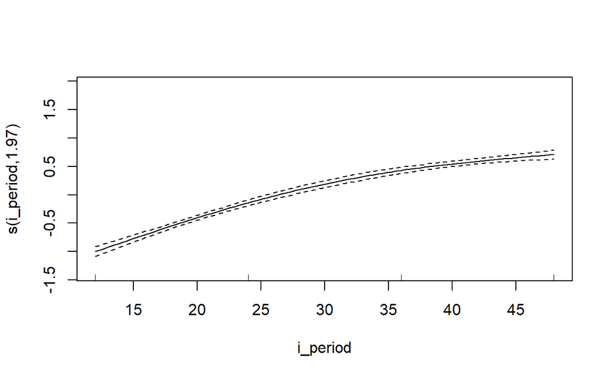

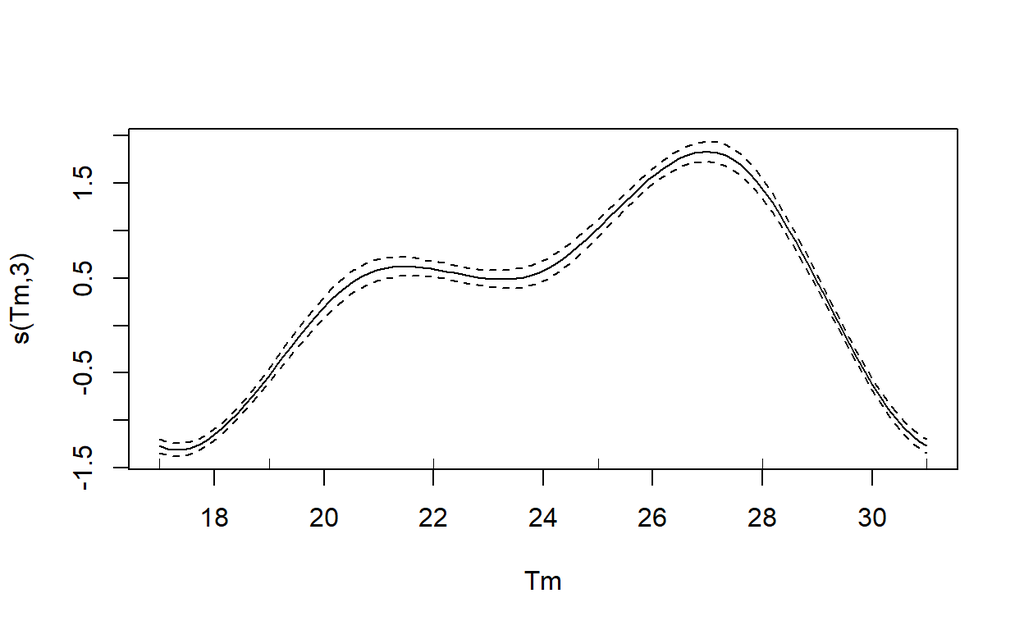

```r
plot(m4)
```

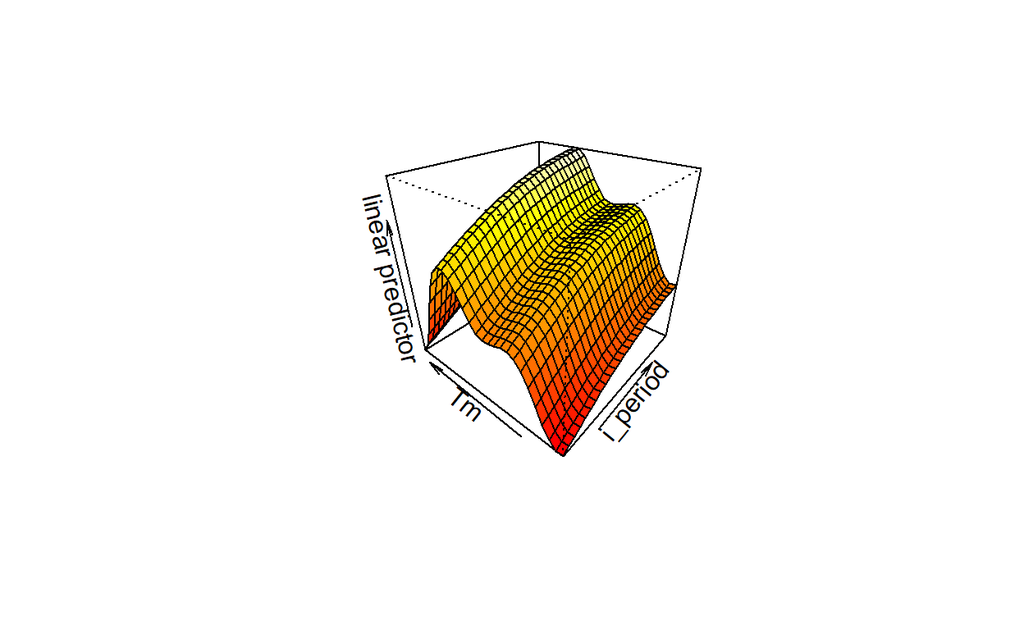

```r
vis.gam(m4,
        theta = -50, # horizontal rotation
        phi = 30, # vertical rotation
        n.grid = max(g_tm$Tm) - min(g_tm$Tm) # grid cells
        )
```

The cyclic P-splines seem to have improved the predictive ability of the model with a very low UBRE, also improving the R squared value and explaining more deviance. We can also see that the curve has been shifted further towards 28C, however the the willingness of the model implies it might be overfit, especially between the temperature ranges 20 - 24C.

Lets compare the models three and four to against each other.

```r
anova(m3,m4, test = "Chisq")
```

```
Analysis of Deviance Table

Model 1: cbind(germ_conidia, non_germ_conidia) ~ s(i_period, k = 3) +
    s(Tm, k = 4, bs = "ps")
Model 2: cbind(germ_conidia, non_germ_conidia) ~ s(i_period, k = 3) +
    s(Tm, k = 4, bs = "cp")
  Resid. Df Resid. Dev          Df Deviance Pr(>Chi)
1    90.001     230.29
2    90.001     122.11 -2.1942e-05   108.18
```

The models show no significant difference, therefore we should keep the simpler model.

Lets use the p splines again however increase the number of knots for temperature in attempt to get a better fit to the raw data.

```r
m5 <- gam(cbind(germ_conidia, non_germ_conidia) ~ s(i_period, k=3) + s(Tm, k =6, bs = "ps"),
          data = g_tm[Tm != 8 & Tm != 35,],
          family = "binomial")
summary(m5)
```

```
Family: binomial
Link function: logit

Formula:
cbind(germ_conidia, non_germ_conidia) ~ s(i_period, k = 3) +
    s(Tm, k = 6, bs = "ps")

Parametric coefficients:
            Estimate Std. Error z value Pr(>|z|)
(Intercept) -0.53611    0.02495  -21.49   <2e-16 ***
---
Signif. codes:  0 '***' 0.001 '**' 0.01 '*' 0.05 '.' 0.1 ' ' 1

Approximate significance of smooth terms:
              edf Ref.df Chi.sq p-value
s(i_period) 1.974  1.999  639.7  <2e-16 ***
s(Tm)       4.990  5.000 1737.2  <2e-16 ***
---
Signif. codes:  0 '***' 0.001 '**' 0.01 '*' 0.05 '.' 0.1 ' ' 1

R-sq.(adj) =  0.971   Deviance explained = 96.5%
UBRE = 0.17866  Scale est. = 1         n = 96
```

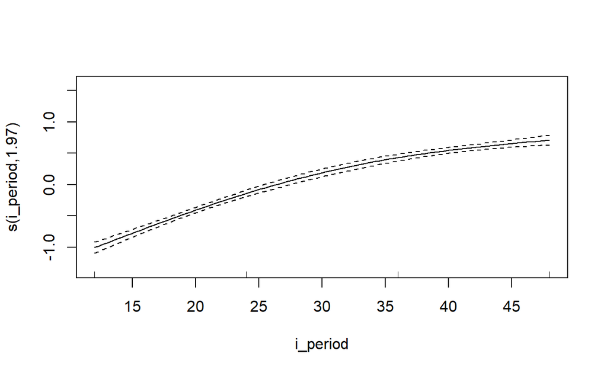

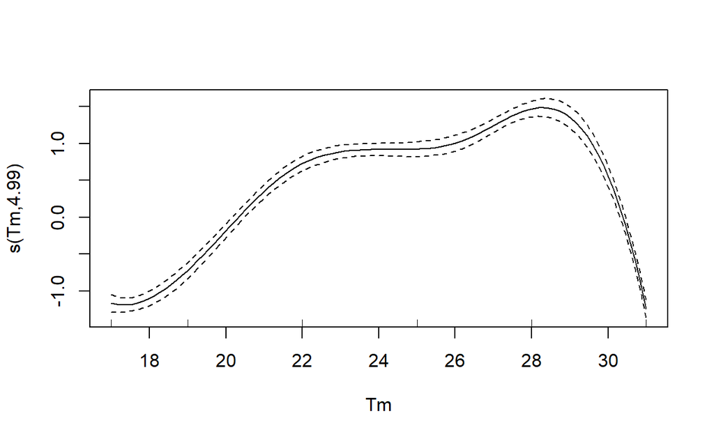

```r
plot(m5)
```

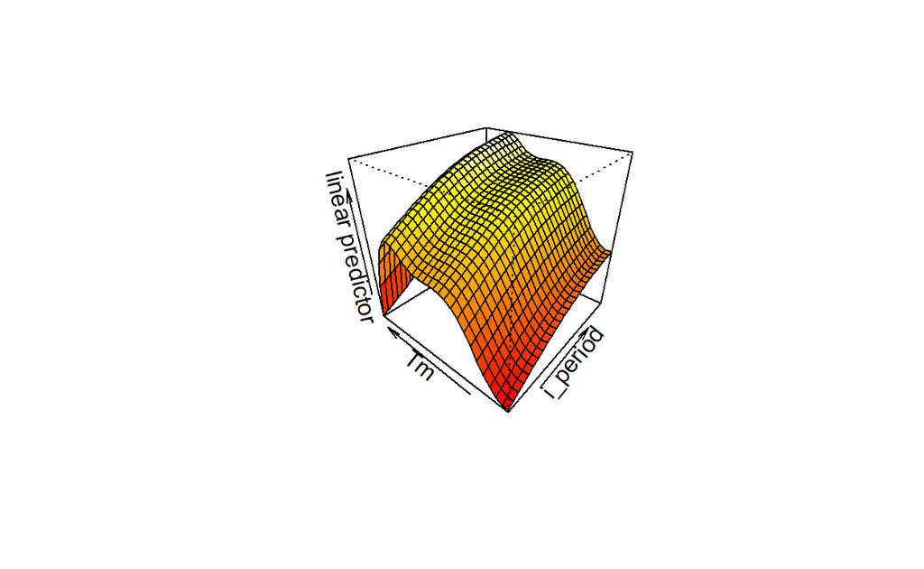

```r
vis.gam(m5,
        theta = -50, # horizontal rotation
        phi = 30, # vertical rotation
        n.grid = max(g_tm$Tm) - min(g_tm$Tm) # grid cells
        )
```

This model has less “wiggliness”, higher R-squared, explained more deviance and has the lowest UBRE score.

Lets compare the models four and five to against each other.

```r
anova(m4,m5, test = "Chisq")
```

```
Analysis of Deviance Table

Model 1: cbind(germ_conidia, non_germ_conidia) ~ s(i_period, k = 3) +
    s(Tm, k = 4, bs = "cp")
Model 2: cbind(germ_conidia, non_germ_conidia) ~ s(i_period, k = 3) +
    s(Tm, k = 6, bs = "ps")
  Resid. Df Resid. Dev Df Deviance  Pr(>Chi)
1    90.001    122.109
2    88.001     97.224  2   24.885 3.948e-06 ***
---
Signif. codes:  0 '***' 0.001 '**' 0.01 '*' 0.05 '.' 0.1 ' ' 1
```

The p-spline model with more knots explained the most deviance and provides a significantly better fit.

And look at the AIC values of all the models.

```r
AIC(m1,m2,m3,m4,m5)
```

```
          df      AIC
m1  5.969536 756.3882
m2 12.907328 716.7909
m3  5.970310 689.6091
m4  5.970871 581.4289
m5  7.963796 560.5300
```

This shows that model five is the best fit, with the lowest AIC and an R squared of 0.9709. Temperature and infection period are significant predictors and the model produces a low UBRE score or 0.179, indicating good predictive ability and less affected by drop one, tests.

## Temperature effect on germtube branching

Peek at the data

```r
head(br_tm)
```

```
   Tm branches rep conidia
1:  8        0   1     100
2:  8        0   2     100
3:  8        1   1       0
4:  8        1   2       0
5:  8        2   1       0
6:  8        2   2       0
```

```r
str(br_tm)
```

```
Classes 'data.table' and 'data.frame':  64 obs. of  4 variables:
 $ Tm      : int  8 8 8 8 8 8 8 8 17 17 ...
 $ branches: int  0 0 1 1 2 2 3 3 0 0 ...
 $ rep     : int  1 2 1 2 1 2 1 2 1 2 ...
 $ conidia : int  100 100 0 0 0 0 0 0 70 70 ...
 - attr(*, ".internal.selfref")=<externalptr>
```

```r
summary(br_tm)
```

```
       Tm           branches         rep         conidia
 Min.   : 8.00   Min.   :0.00   Min.   :1.0   Min.   :  0.0
 1st Qu.:18.50   1st Qu.:0.75   1st Qu.:1.0   1st Qu.:  0.0
 Median :23.50   Median :1.50   Median :1.5   Median : 15.0
 Mean   :23.12   Mean   :1.50   Mean   :1.5   Mean   : 25.0
 3rd Qu.:28.75   3rd Qu.:2.25   3rd Qu.:2.0   3rd Qu.: 37.5
 Max.   :35.00   Max.   :3.00   Max.   :2.0   Max.   :100.0
```

This experiment used the same leaves as the germination experiment which were incubated for 36 hours. Following 36 hours of incubation at each respective temperatures, four leaf discs were removed from the growth chamber and sticky tape used to make a slide of the conidia from the surface of the leaf. Two additional leaf discs were removed from the same chamber at the same time, stained and fixed for microscopy using the leaf clearing method, described by Jose Liberato. One hundred conidia were selected at random and the state of germination or branching recorded.

### Visualise the raw data  
Let’s plot the data over time

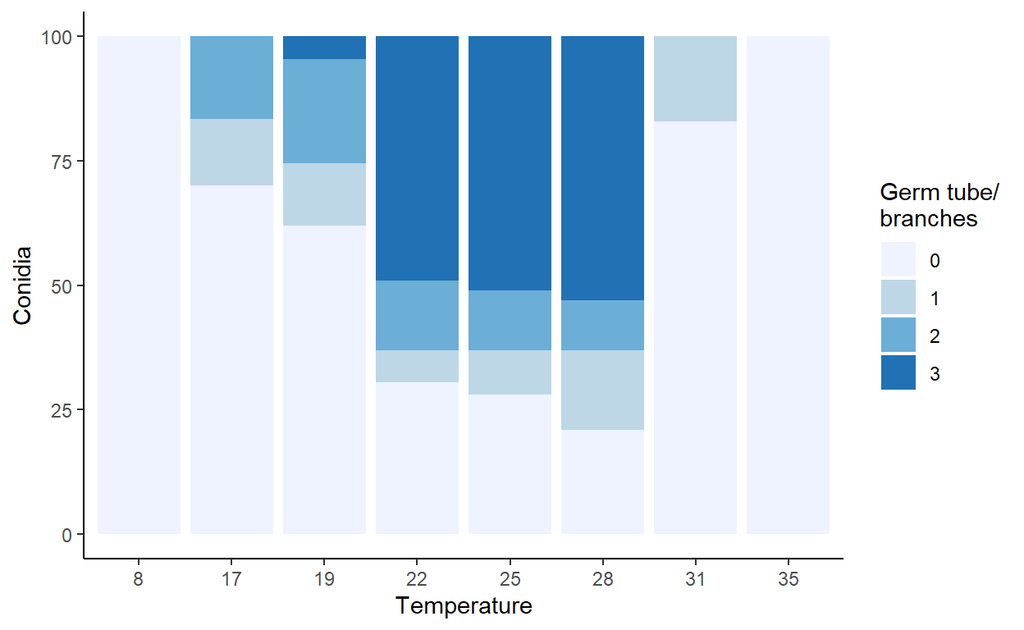

```r
br_tm |>
   ggplot(aes( x = as.factor(Tm), y = conidia/2 , fill = as.factor(branches))) +
   geom_col(position = position_stack(reverse = TRUE))+
   scale_fill_brewer(palette = "Blues", name = "Germ tube/\nbranches")+
   xlab("Temperature")+
   ylab("Conidia")+
   labs(colour = "Germ tubes")+
   theme_classic()
```

This plot shows that the optimum temperature for rapid *P. xanthii* germination is around 28C. Also, no germination occurs at temperatures 8$^\circ$C or less, and over 35$^\circ$C.

Lets build a model to help us predict what state a conidia will be in, after 36 hours when incubated at each respective temperature.

Here we have a response variable, `branches` which describes the progress of a potential infection by a single conidia.  
- `0` which represents a non-germinated conidia,  
- `1` a germinated conidia with one germ tube,  
- `2` a germinated conidia with two germ tubes,  
- `3` a germinated conidia with three or more germ tubes.

The response variable is might be thought of as continuous. However the given our aim is to estimate the survival of conidia on a cucurbit leaf, and if successful infection might occur estimating the number of branched hyphae beyond three is meaningless, given Trecate (2019) assumes successful infection of a host cell if there are more than 2 germ tubes. `branches` would be better characterised as ordinal and therefore leads us to using *ordinal logistic regression* methods.

### Ordinal logistic regression

The aim of this analysis is to predict the likelihood of a conidia germinating and branching under different temperature conditions.  
We could state that the response variable is the state of the conidia, wheather it be non-germinated (0), germinated (1), branched (2), or twice branched (3) with three germ-tubes. Because this is count data and our response is not binomial but multinomial and ordered,the type of analysis we should use is an ordinal logistic regression.

First we need to convert the count data into a longer format, so each row represents an observation.

```r
br_tm_lng <-
   rbindlist(apply(br_tm, 1 , function(x) {
      rbindlist(lapply(seq_len(x["conidia"]), function(x2) {
         as.data.frame(t(x[c(1:3)]))
      }))
   }))

# classify each column
br_tm_lng[, c("Tm", "branches", "rep") := list(Tm,
                                               ordered(branches),
                                               as.factor(rep))]
```

Now we have prepared our data lets try it in our first model.

```r
m1 <- polr(branches ~ Tm + rep,
           data = br_tm_lng,
           Hess = TRUE)

summary(m1)
```

```
Call:
polr(formula = branches ~ Tm + rep, data = br_tm_lng, Hess = TRUE)

Coefficients:
       Value Std. Error t value
Tm   0.02208   0.006384  3.4580
rep2 0.01755   0.100010  0.1755

Intercepts:
    Value   Std. Error t value
0|1  1.0022  0.1657     6.0473
1|2  1.4227  0.1670     8.5171
2|3  1.9288  0.1701    11.3379

Residual Deviance: 3372.54
AIC: 3382.54
```

The output is in proportional log odds and presents *Coefficients* which represent the change in log odds for each unit of the predictor. For example for each degree temperature increases the log odds increases 0.022.

The coefficient `rep` is not significiant and can probably be dropped from the model.

Lets plot the model predictions for temperatures between 8$^\circ$ C and 35$^\circ$ C to determine if the result is reasonable compared to the raw data.

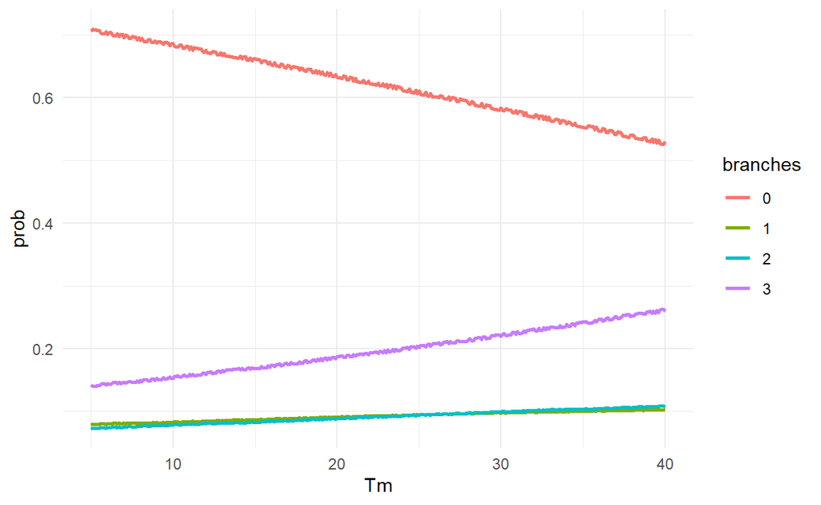

```r
# Make a data.frame of test values to feed in the model
test_dat <- data.table(Tm = seq(from = 5, to = 40, by = 0.1), # between 5 and 8 degrees
                       rep = as.factor(rbinom(length(seq(from = 5, to = 40, by = 0.1)),1,0.5)+1)) # randomly use either the first or second rep

# create a data.frame with predicted values and reference them to the respective temperature
m1_pred <-
   as.data.table(cbind(Tm = test_dat$Tm,
                       round(predict(m1,
                                     test_dat,
                                     type = "p"),
                             3)))

# format to long
m1_pred <-
   melt(
      m1_pred,
      id.vars = "Tm",
      measure.vars = c("0", "1", "2", "3"),
      variable.name = "branches",
      value.name = "prob"
   )

m1_pred |>
   ggplot(aes(Tm, prob, colour = branches))+
   geom_line(size = 1)+
   theme_minimal()
```

The result is rather linear and predicts more branches at 40C when the raw data does not see any from 35C or presumably above.

Lets try applying some splines to temperature and dropping rep.

```r
library(splines)
m2 <- polr(branches ~ bs(Tm,Boundary.knots = c(8,35)),
                         data = br_tm_lng, Hess = TRUE)
summary(m2)
```

```
Call:
polr(formula = branches ~ bs(Tm, Boundary.knots = c(8, 35)),
    data = br_tm_lng, Hess = TRUE)

Coefficients:
                                     Value Std. Error t value
bs(Tm, Boundary.knots = c(8, 35))1  0.1975     1.6404  0.1204
bs(Tm, Boundary.knots = c(8, 35))2 16.6471     0.8822 18.8701
bs(Tm, Boundary.knots = c(8, 35))3 -2.8168     1.1639 -2.4202

Intercepts:
    Value   Std. Error t value
0|1  5.0417  0.8499     5.9319
1|2  5.6921  0.8513     6.6867
2|3  6.4421  0.8529     7.5529

Residual Deviance: 2539.384
AIC: 2551.384
```

The residual deviance and AIC on this model is lower, indicating this might be a better fit. Also the t value is higher hinting this model shows clearer differences between the variables.

Now lets try predicting from this model.

```r
m2_pred <- as.data.table(round(predict(m2,
                         test_dat,
                         type = "p"),
                 3))[, Tm := test_dat$Tm]
```

We get a warning indicating the the predicted values are outside the range of the spline boundary knots. This is ok as we know there should be a zero probability of spore germination outside this temperature range of 8$^\circ$C and 35$^\circ$C

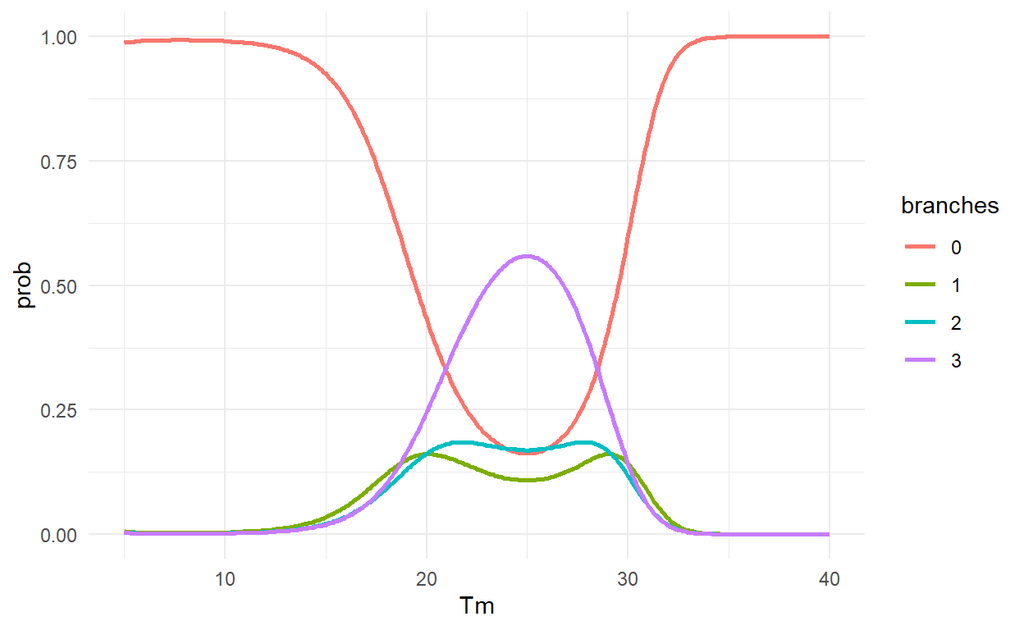

```r
# format to long
m2_pred <-
   melt(
      m2_pred,
      id.vars = "Tm",
      measure.vars = c("0", "1", "2", "3"),
      variable.name = "branches",
      value.name = "prob"
   )

m2_pred |>
   ggplot(aes(Tm, prob, colour = branches))+
   geom_line(size = 1)+
   theme_minimal()
```

This plot looks like it would fit the raw data much better than `m1`. However, the model is more centered on 25$^\circ$C as the temperature producing the most germinated conidia with three germ-tubes. Lets see if we can improve the model by adding more knots.

```r
m3 <- polr(branches ~ bs(Tm,
                         knots = c(19,23,27,30)),
                         data = br_tm_lng, Hess = TRUE)
summary(m3)
```

```
Call:
polr(formula = branches ~ bs(Tm, knots = c(19, 23, 27, 30)),
    data = br_tm_lng, Hess = TRUE)

Coefficients:
                                    Value Std. Error  t value
bs(Tm, knots = c(19, 23, 27, 30))1 15.009    40.5865  0.36979
bs(Tm, knots = c(19, 23, 27, 30))2  8.925    38.3956  0.23246
bs(Tm, knots = c(19, 23, 27, 30))3 15.293    38.8312  0.39383
bs(Tm, knots = c(19, 23, 27, 30))4 12.718    38.6486  0.32907
bs(Tm, knots = c(19, 23, 27, 30))5 16.338    38.8583  0.42044
bs(Tm, knots = c(19, 23, 27, 30))6  1.130    39.5542  0.02856
bs(Tm, knots = c(19, 23, 27, 30))7 -7.676     0.9026 -8.50526

Intercepts:
    Value   Std. Error t value
0|1 12.6119 38.7288     0.3256
1|2 13.2755 38.7289     0.3428
2|3 14.0390 38.7289     0.3625

Residual Deviance: 2501.665
AIC: 2521.665
```

Now lets try predicting from this model.

```r
m3_pred <- as.data.table(round(predict(m3,
                         test_dat[,1],
                         type = "p"),
                 3))[, Tm := test_dat$Tm]
```

We get a warning indicating the the predicted values are outside the range of the spline boundary knots. This is ok as we know there should be a zero probability of spore germination outside this temperature range of 8$^\circ$C and 35$^\circ$C

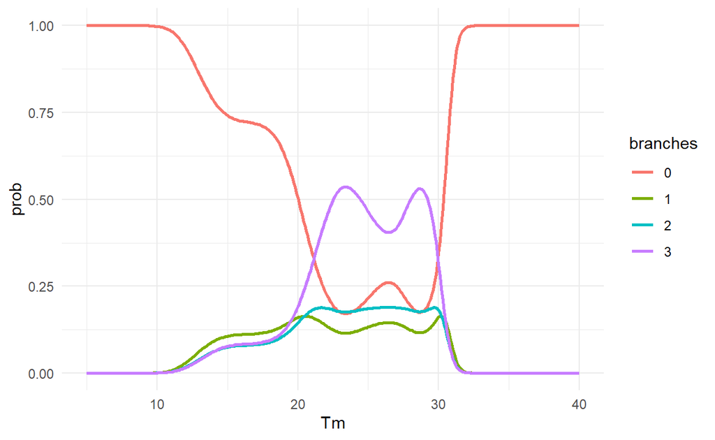

```r
# format to long
m3_pred <-
   melt(
      m3_pred,
      id.vars = "Tm",
      measure.vars = c("0", "1", "2", "3"),
      variable.name = "branches",
      value.name = "prob"
   )

m3_pred |>
   ggplot(aes(Tm, prob, colour = branches))+
   geom_line(size = 1)+
   theme_minimal()
```

The plot shows that this model might have too many spline knots. Lets compare the mode using the `anova()` function.

```r
anova(m2,m3)
```

```
Likelihood ratio tests of ordinal regression models

Response: branches
                              Model Resid. df Resid. Dev   Test    Df
1 bs(Tm, Boundary.knots = c(8, 35))      1594   2539.384
2 bs(Tm, knots = c(19, 23, 27, 30))      1590   2501.665 1 vs 2     4
  LR stat.      Pr(Chi)
1
2  37.7193 1.280351e-07
```

While the anova says `m3` is a significantly better model, the residual deviance informs us it is not by much. Based on the plot we will try fewer knots to reduce the wiggliness

```r
m4 <- polr(branches ~ bs(Tm,
                         knots = c(23,28)
                         ),
                         data = br_tm_lng, Hess = TRUE)
summary(m4)
```

```
Call:
polr(formula = branches ~ bs(Tm, knots = c(23, 28)), data = br_tm_lng,
    Hess = TRUE)

Coefficients:
                             Value Std. Error t value
bs(Tm, knots = c(23, 28))1   2.455      2.366   1.037
bs(Tm, knots = c(23, 28))2   8.255      1.780   4.638
bs(Tm, knots = c(23, 28))3   7.719      2.017   3.827
bs(Tm, knots = c(23, 28))4   8.419      2.539   3.317
bs(Tm, knots = c(23, 28))5 -33.997     11.786  -2.884

Intercepts:
    Value    Std. Error t value
0|1   6.5111   1.8145     3.5883
1|2   7.1687   1.8151     3.9496
2|3   7.9200   1.8154     4.3626

Residual Deviance: 2517.106
AIC: 2533.106
```

Now lets try predicting from this model.

```r
m4_pred <-
   as.data.table(round(predict(m4,
                               test_dat[, 1],
                               type = "p",
                               se.fit = TRUE),
                       3))[, Tm := test_dat$Tm]
```

We get a warning indicating the the predicted values are outside the range of the spline boundary knots. This is ok as we know there should be a zero probability of spore germination outside this temperature range of 8$^\circ$C and 35$^\circ$C

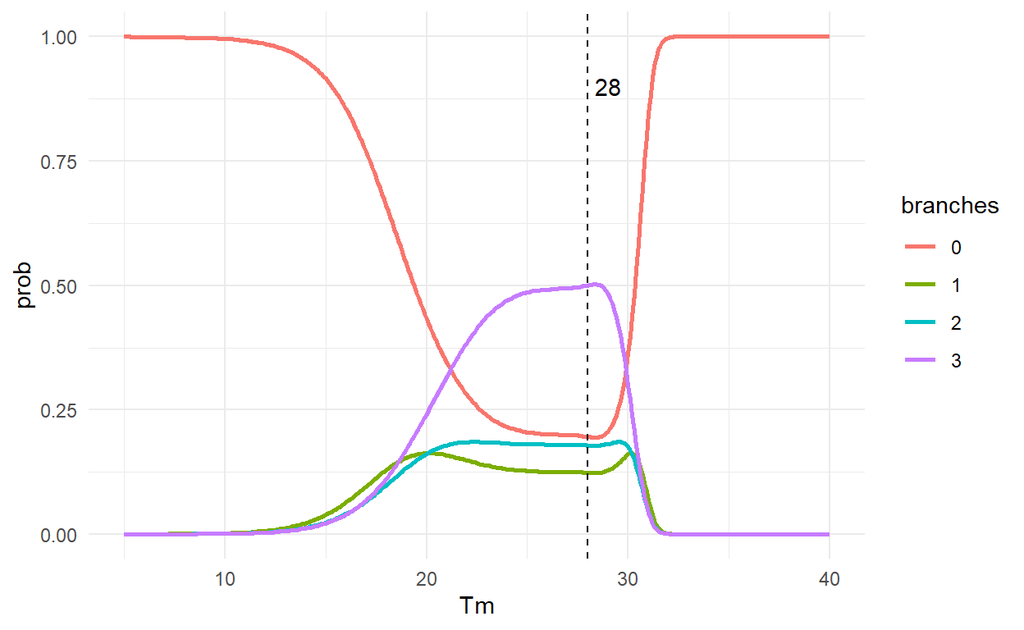

```r
# format to long
m4_pred <-
   melt(
      m4_pred,
      id.vars = "Tm",
      measure.vars = c("0", "1", "2", "3"),
      variable.name = "branches",
      value.name = "prob"
   )

m4_pred |>
   ggplot(aes(Tm, prob, colour = branches))+
   geom_line(size = 1)+
   theme_minimal()+
   geom_vline(aes(xintercept = 28), linetype = 2)+
   annotate(geom = "text",
            x = 29,
            y = 0.9,
            label = 28)
```

The plot shows a smoother fit with the knots we have tried. Lets compare the model using the `anova()` function.

```r
anova(m3,m4)
```

```
Likelihood ratio tests of ordinal regression models

Response: branches
                              Model Resid. df Resid. Dev   Test    Df
1         bs(Tm, knots = c(23, 28))      1592   2517.106
2 bs(Tm, knots = c(19, 23, 27, 30))      1590   2501.665 1 vs 2     2
  LR stat.     Pr(Chi)
1
2 15.44083 0.000443676
```

While the anova says `m3` is a significantly better model, the residual deviance informs us it is not by much. Because the plot of `m4` seems a more reasonable fit to the data, we will use this.

Lets examine the coefficients.

```r
coef(m4)
```

```
bs(Tm, knots = c(23, 28))1 bs(Tm, knots = c(23, 28))2
                  2.454674                   8.255239
bs(Tm, knots = c(23, 28))3 bs(Tm, knots = c(23, 28))4
                  7.718719                   8.419468
bs(Tm, knots = c(23, 28))5
                -33.996879
```

There are five coefficients for the Temperature variable because the b-spline breaks the data into different ranges depending on `knot` placement. Here we see there are four knots at the following temperatures

```r
tm_bs <- bs(br_tm_lng$Tm, knots = c(23,28))
sort(c(attr(tm_bs, which = "knots"),
  attr(tm_bs, which = "Boundary.knots")))
```

```
[1]  8 23 28 35
```

As can be seen in the summary above it is a little hard to make sense of these values. The spline breaks up the temperature predictor into five predictors, each explaining the difference between temperatures for a particular range. The value gives us a scaled representation of the mean magnitude of each temperature range on a log odds scale, and therefore the only inference we can make from these values is some are greater some are less and some have a large negative influence on spore germination state.

The significance of each predictor can be observed by the standard error or the ‘t value’ $t value = \frac{coef}{se}$. We can also obtain P-values from this output, however these methods are not advised given they assume a normal distribution and infinite degrees of freedom.

```r
# get table of coefficients
coef_table <- data.table(coef(summary(m4)), keep.rownames = TRUE)

# calculate p-values
coef_table[, p_value := pnorm(abs(`t value`),lower.tail = FALSE) *2]
coef_table
```

```
                           rn      Value Std. Error   t value
1: bs(Tm, knots = c(23, 28))1   2.454674   2.366050  1.037456
2: bs(Tm, knots = c(23, 28))2   8.255239   1.779860  4.638138
3: bs(Tm, knots = c(23, 28))3   7.718719   2.016666  3.827465
4: bs(Tm, knots = c(23, 28))4   8.419468   2.538598  3.316582
5: bs(Tm, knots = c(23, 28))5 -33.996879  11.786364 -2.884425
6:                        0|1   6.511094   1.814542  3.588284
7:                        1|2   7.168750   1.815077  3.949557
8:                        2|3   7.919989   1.815447  4.362556
        p_value
1: 2.995232e-01
2: 3.515620e-06
3: 1.294697e-04
4: 9.112572e-04
5: 3.921296e-03
6: 3.328613e-04
7: 7.829585e-05
8: 1.285514e-05
```

Perhaps a better method for inferring statistical significance is to consider the confidence intervals and if the CI includes zero.

```r
m4_ci <- confint(m4)
m4_ci
```

```
                                 2.5 %    97.5 %
bs(Tm, knots = c(23, 28))1  -0.9261495  10.34610
bs(Tm, knots = c(23, 28))2   5.6446504  14.10850
bs(Tm, knots = c(23, 28))3   4.9189731  14.53761
bs(Tm, knots = c(23, 28))4   3.6682267  14.58982
bs(Tm, knots = c(23, 28))5 -56.5696386 -10.20560
```

So for temperatures < 8$^\circ$C the coefficient was 2.4546742, with CIs that include zero indicating little difference between the number of conidial germ-tubes at temperature treatments in this range.

For temperatures 8$^\circ$C < `Tm` < 23$^\circ$C the coefficient was 8.2552385, with CIs that *don’t* include zero indicating a likely significant difference between the proportions of conidia with varying numbers of germ-tubes due to temperatures in this range.

For temperatures 23$^\circ$C < `Tm` < 28$^\circ$C the coefficient was 7.7187186, with CIs that *don’t* include zero indicating a likely significant difference between the proportions of conidia with varying numbers of germ-tubes due to temperatures in this range.

For temperatures 28$^\circ$C < `Tm` < 35$^\circ$C the coefficient was 8.4194678, with CIs that *don’t* include zero indicating a likely significant difference between the proportions of conidia with varying numbers of germ-tubes due to temperatures in this range.

For temperatures 35$^\circ$C < `Tm` the coefficient was -33.9968787, with CIs that *don’t* include zero indicating a likely significant difference and negative association between the proportions of conidia with varying numbers of germ-tubes due to temperatures in this range.

$\frac{t}{13.3}I(0<=t<13.3)+\frac{38.83333-t}{38.83333-13.3}I(13.3<=t<38.83333)$